# STAT 331 Final Report

- Show All Code
- Hide All Code
- View Source

Author

Ellexis Monsanto, Sophie Russ, Emma Siskens

### Read in Data + Load Libraries

```r
library(tidyverse)
library(broom)
library(knitr)
library(kableExtra)
library(patchwork)
library(scales)
fertility <- read_csv("children.csv")
gdp <- read_csv("gdp.csv")
```

# 1 Data

## 1.1 Introduction: Describing Data

We are interested in exploring the relationship between the two variables “GDP per capita” and “Total Fertility Rate”. We retrieved datasets on these two variables from Gapminder.org.

The dataset `gdp.csv` contains the gross domestic product (GDP) per person (capita) for 195 countries from 1800 to 2100, with each year a column (variable) and each country a row (observation). GDP per capita “measures the value of everything produced in a country during a year, divided by the number of people” (Gapminder). The unit is international dollars, fixed to 2017 prices adjusted for inflation and differences in cost of living, known as PPP dollars. Although flawed, GDP per capita is often used as a core indicator of a country’s economic performance and average living standards. Gapminder’s dataset has predicted data up to 2100 [using forecasts and predictive modeling](https://www.gapminder.org/data/documentation/gd001/). However, for the scope of our project, we will focus on data up to 2024.

The dataset `children.csv` contains the number of babies per woman (Total Fertility Rate) for 202 countries from 1800 to 2100, with each year a column (variable) and each country a row (observation). Total Fertility Rate is “the number of children that would be born to each woman with prevailing age-specific fertility rates” (Gapminder). Gapminder’s dataset uses estimates from the UN for most of its data and has predicted data up to 2100 using the UN projection of future fertility rate in all countries. However, for the scope of our project, we will focus on data up to 2024.

We hypothesize that there will be a **negative** association between GDP per capita and Total Fertility Rate. Our explanatory variable will be GDP per capita and our response variable of interest will be Total Fertility Rate. Through internet research, we found that, in general, poor countries tend to have higher levels of fertility than rich countries ([Vandenbroucke](https://www.stlouisfed.org/on-the-economy/2016/december/link-fertility-income)). We are interested in exploring and confirming (or refuting) this relationship in general and over time with the time series data that we have.

## 1.2 Cleaning Data

To prepare our data for analysis, we pivoted each dataset to long format to get the year to be a single column. We converted the `year` variable to numeric and filtered the data to only include years up to 2024. For the GDP per capita dataset, we had to convert all “k” values (i.e. “90k”) to numeric and multiply by 1000. We also dropped all missing values in both datasets. Then, we merged both datasets using an inner join to only contain observations that have values for both gdp and fertility.

### Cleaning `fertility.csv`

```r
fertility_long <- fertility |>
  pivot_longer(cols = c("1800":"2100"),
               names_to = "year",
               values_to = "fertility") |>
  mutate(year = as.numeric(year)) |>
  filter(year < 2025) |>
  drop_na()
```

### Cleaning `gdp.csv`

```r
gdp_long <- gdp |>
  mutate(across(c("1800":"2100"),
                ~ifelse(str_detect(.x, "k"),
                        as.numeric(str_replace_all(.x, "k", ""))*1000,
                        as.numeric(.x)))) |>
  pivot_longer(cols = c("1800":"2100"),
               names_to = "year",
               values_to = "gdp") |>
  mutate(year = as.numeric(year)) |>
  filter(year < 2025) |>
  drop_na()
```

### Combining both datasets

Our final cleaned and merged dataset `fertility_gdp` has 4 variables: country (character), year (numeric), gdp (numeric), and fertility (numeric). It contains data on 186 countries in total from the years 1800-2024.

```r
fertility_gdp <- gdp_long |>
  inner_join(fertility_long)
```

# 2 Linear Regression

## 2.1 Data Visualization

We will begin by investigating visualization of data on Gross Domestic Product and Fertility rate. First off, we investigate the relationship of Gross Domestic Product and Fertility in different centuries. We calculate the mean GDP and mean fertility for each country, for each 50-year time-span (1800-1850 to 2000-present). This results in 5 data points per country. We graph average gdp per country to average fertility rate per country, and facet by each 50-year time period in the following graphic.

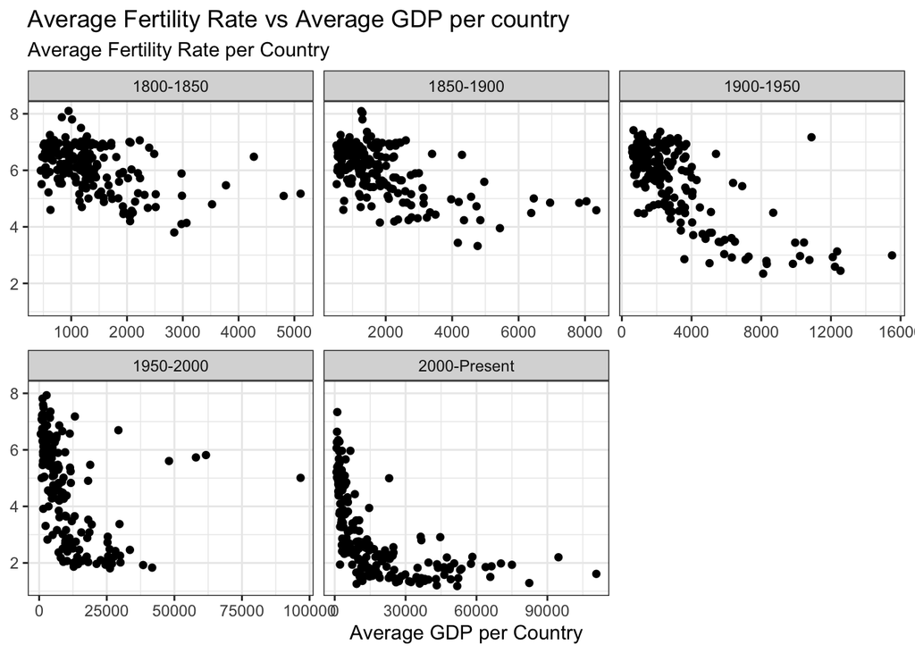

```r
map_to_decade <- function(year) {
  if (year < 1850) {
    return("1800-1850")
  } else if (year < 1900) {
    return("1850-1900")
  } else if (year < 1950) {
    return("1900-1950")
  } else if (year < 2000) {
    return("1950-2000")
  } else {
    return("2000-Present")
  }
}

avg_fertility_gdp_years <- fertility_gdp |>
  mutate(decade = case_when(
    year < 1850 ~ "1800-1850",
    year < 1900 ~ "1850-1900",
    year < 1950 ~ "1900-1950",
    year < 2000 ~ "1950-2000",
    .default = "2000-Present")) |>
  group_by(country, decade)|>
  summarise(avg_fertility = mean(fertility), avg_gdp = mean(gdp))

ggplot(aes(x = avg_gdp,
             y = avg_fertility),
       data = avg_fertility_gdp_years) +
  geom_point()+
  labs(title = "Average Fertility Rate vs Average GDP per country",
       subtitle = "Average Fertility Rate per Country",
       y = NULL,
       x = "Average GDP per Country") +
facet_wrap(. ~ decade, scales = "free_x") +

theme_bw()
```

From the visualization, we see how the relationship between GDP and fertility changes over each 50-year period. In the first frame (1800-1850), there is a flat and linear relationship; most countries have a fertility rate of 6 children, regardless of GDP. In the next frame, we still observe a linear, flat relationship, but countries are starting to have increased GDPs. In the third frame (1900 to 1950), we observe that industrialized countries start to pull away in GDP by almost double. A pattern starts to emerge where fertility decreases as GDP increases. This relationship is further supported in the fourth frame (1950-2000), where there is a more defined drop in fertility to 2 children, once the GDP hits $20,000. In the last frame (2000 to present), more countries hit the GDP of over $20,000, and the drastic drop in fertility to 2 children is further observed. Thus, from graphing the relationship between GDP and fertility rate (and freeing the x-axis), the data shows an inverse relationship over time; as GDP increases, fertility rate decreases exponentially.

Next, we investigate the overall relationship between average GDP and average fertility for all countries across all years, from 1800 to present. This is visualized in the following graphic.

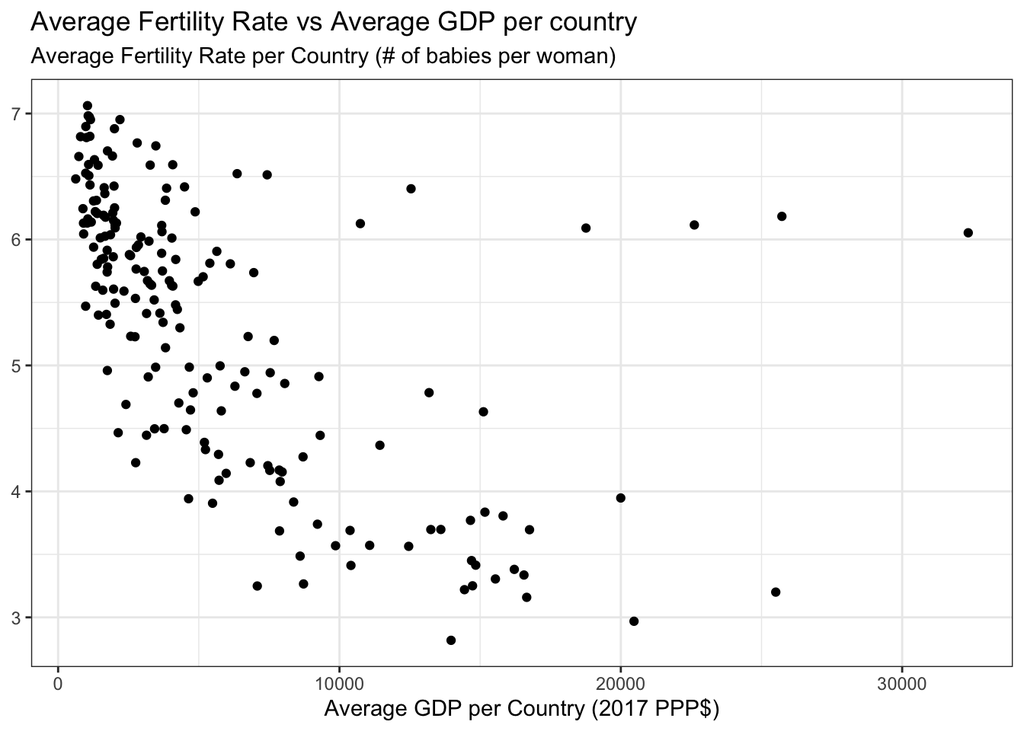

```r
avg_fertility_gdp <- fertility_gdp |>
  group_by(country)|>
  summarise(avg_fertility = mean(fertility), avg_gdp = mean(gdp))

ggplot(aes(x = avg_gdp,
             y = avg_fertility),
       data = avg_fertility_gdp) +
  geom_point()+
  labs(title = "Average Fertility Rate vs Average GDP per country",
       subtitle = "Average Fertility Rate per Country (# of babies per woman)",
       y = NULL,
       x = "Average GDP per Country (2017 PPP$)")+
  theme_bw()
```

In this graph, we can see that as average GDP increases, the average Fertility rate tends to decrease. We can also see that the majority of the countries have an average GDP under $10,000 and an average fertility rate above 4 children per woman. There seems to be an evident negative relationship. However there may be some curvature indicating a negative exponential form rather than a true linear form. Additionally, the relationship is not very strong as the data points at increased average GDP values are more spread out.

## 2.2 Linear Regression

In this exploration, we will create a simple linear regression model to attempt to fit our data. Simple Linear regression assumes a linear relationship between the variables, average GDP and average Fertility rate, as well as normally distributed, independent errors with a mean of 0 and equal variance.

After fitting the data, the estimated linear regression model is as follows:

```r
model <- lm(avg_fertility ~ avg_gdp, data = avg_fertility_gdp)
tidy(model) |>
  transmute(
    term,
    coefficient = round(estimate, 5),
    std.error = round(std.error, 4),
    `t-statistic` = round(statistic, 2),
    `p-value` = scales::pvalue(p.value)
  ) |>
  knitr::kable()
```

| term | coefficient | std.error | t-statistic | p-value |
| --- | --- | --- | --- | --- |
| (Intercept) | 5.98389 | 0.0926 | 64.61 | <0.001 |
| avg_gdp | -0.00012 | 0.0000 | -9.97 | <0.001 |

From the table, the estimated linear regression equation is $\widehat{Average Fertility}=5.98389-0.00012(AverageGDP)$

### Coefficient Interpretations

The estimated intercept of the model was 5.98389. When the country’s average GDP over the years 1800 to 2024 is equal to zero, the country’s estimated average fertility rate is 5.98389 babies per woman.

The estimated slope coefficient for Average GDP was -0.00012. For every $1 (in PPP 2017 dollars) increase in country’s average GDP, the country’s estimated average fertility rate is estimated to decrease by 0.00012 babies per woman. Equivalently, for every $10,000 (in PPP 2017 dollars) increase in country’s average GDP the country’s estimated average fertility rate is estimated to decrease by 1.2 babies per woman.

### Assessing Model Fit

As for assessing the fit of our model, we can refer to the following table of variances:

```r
variances <- data.frame(
  response_variance = var(avg_fertility_gdp$avg_fertility),
  fitted_variance = var(model$fitted.values),
  residual_variance = var(model$residuals)
)

variances |>
knitr::kable(digits = 2, col.names = gsub("[_]", " ", names(variances)))
```

| response variance | fitted variance | residual variance |
| --- | --- | --- |
| 1.18 | 0.41 | 0.76 |

This table shows that about 0.414/1.179 = 0.351, or about 35.1% of the variability in the average fertility rate values was accounted for by our regression model. This is a somewhat low amount of variability being explained, as there is about 0.765/1.179 = 0.649, or about 64.9% of variability in the response still left unexplained by the model with only average GDP as the predictor.

Considering how many factors influence Fertility rate overall, being able to explain 35.1% of its variability is somewhat impressive. Still, only looking at R-squared, our simple linear regression model with average GDP as the predictor is not ideal. The remaining variability could be explained with a more complex model that looks at other factors influencing Fertility rate.

Next, we will assess the linear regression assumptions for our model.

### Linearity Assumption

From our plot of average GDP vs. average Fertility Rate in section 2.1, we can see that the data may not follow a linear relationship. The form of the observations seems to be more curved, and therefore the linearity assumption may be violated.

### Independence Assumption

Since the response variable in our model is average fertility rate for every country, taken over time, we can assume that the observations are independent of one another. That is, the average fertility rate of one country does not influence that of another country. Thus, we can assume that the independence assumption is reasonably met for the model.

### Normal Distribution of Errors Assumption

To assess the distribution of our errors we look at the following plot of residuals.

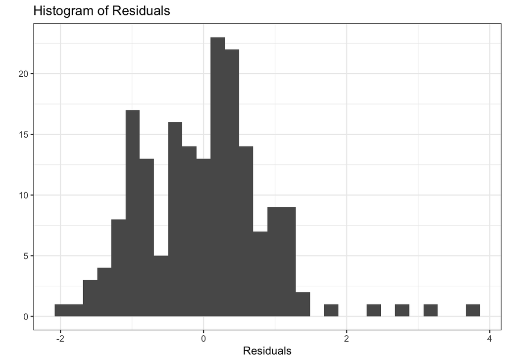

```r
errors <- resid(model)
error_df <- data.frame(Errors = errors)
error_df|>
  ggplot(mapping = aes(x = Errors)) +
  geom_histogram() +
  labs(y = "",
       x = "Residuals",
       title = "Histogram of Residuals")+
  theme_bw()
```

This plot somewhat resembles a bell-curve. There are a few values that are unusually large, and they may be outliers. Nonetheless, we can conclude that the normality assumption is reasonably met.

### Equal Variance Assumption

To assess the variance of our errors, we look at the following plot.

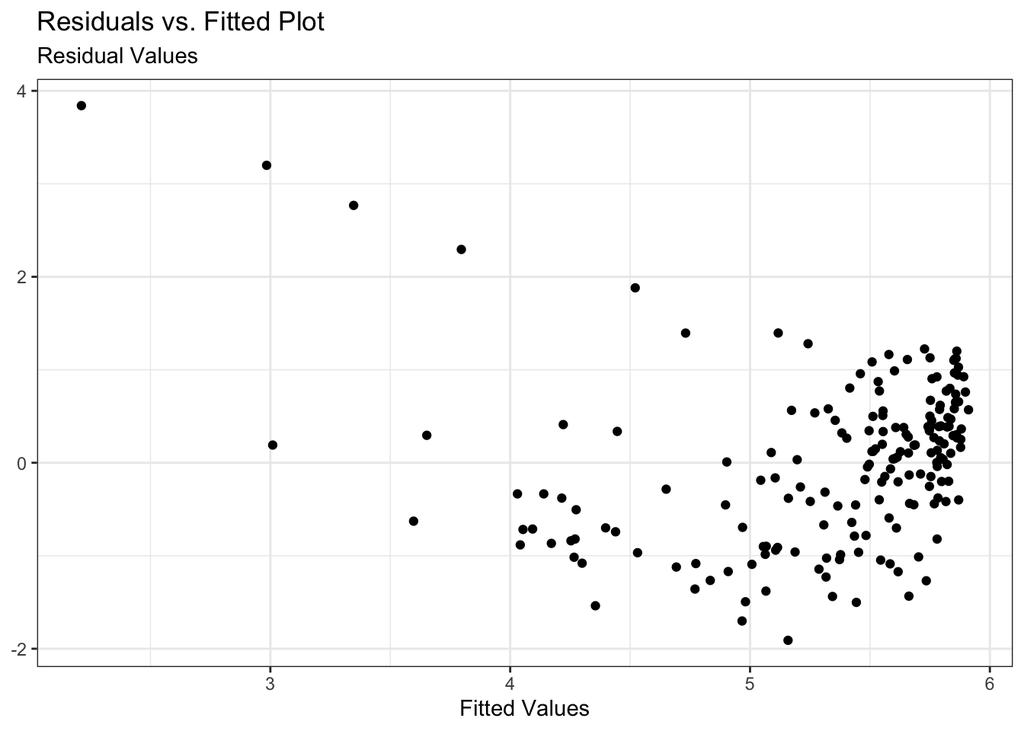

```r
model |>
  augment()|>
  ggplot(aes(x = .fitted,
             y=.resid)) +
  geom_point() +
  labs(x = "Fitted Values",
       y = NULL,
       subtitle = "Residual Values",
       title = "Residuals vs. Fitted Plot")+
  theme_bw()
```

In this plot of fitted values versus residuals, we can see some fanning in the data points. This indicates that the equal variance assumption is violated.

Due to the violation of the assumptions of linearity and equal variance, we should be cautious of performing linear regression for this dataset. Next, we will further assess our linear regression model with the use of simulation.

# 3 Simulation

We will now generate a predictive check, to assess how well our model is performing. We simulate data from our linear regression model and then compare this to the actual observed data points, reporting the proportion of variability explained.

## 3.1 Visualizing Simulation from the Model

In the following graphic, we visualize a single simulation of data from our model next to the actual observations.

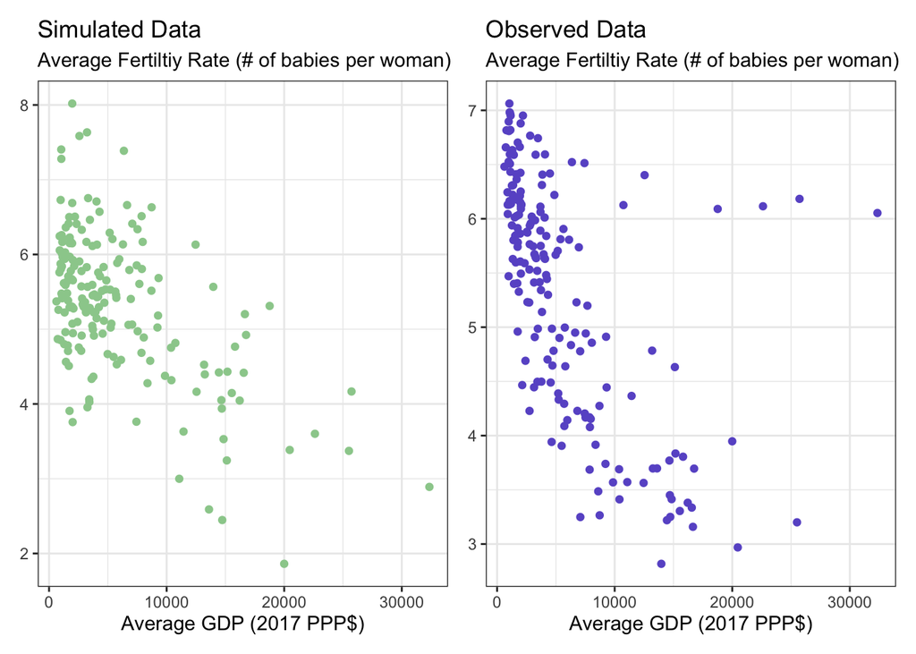

```r
set.seed(100)

pred <- predict(model)
rse <- sigma(model)

noise <- function (x, sd){
  x + rnorm(length(x), mean = 0, sd)

}

predicted_er <- noise(pred, rse)

data <- data.frame(avg_gdp = avg_fertility_gdp$avg_gdp, pred_er = predicted_er)

data_both <- data.frame(
  avg_gdp = avg_fertility_gdp$avg_gdp,
  pred_fertility = predicted_er,
  avg_fertility = avg_fertility_gdp$avg_fertility)

plot_pred <- ggplot(data = data_both, aes(x = avg_gdp)) +

geom_point(aes(y = predicted_er), color = "darkseagreen3") +
  labs(title = "Simulated Data",
       x = "Average GDP (2017 PPP$)",
       y = NULL,
       subtitle = "Average Fertiltiy Rate (# of babies per woman)") +
  theme_bw()


plot_obs <- ggplot(data = data_both, aes(x = avg_gdp)) +
geom_point(aes(y = avg_fertility), color = "slateblue") +
    labs(title = "Observed Data",
       x = "Average GDP (2017 PPP$)",
       y = NULL,
       subtitle = "Average Fertiltiy Rate (# of babies per woman)") +
  theme_bw()

plot_combined <- plot_pred + plot_obs
plot_combined
```

From this graphic, we can see that our simulated data differs from our observed data. Both graphs have a negative association and are right skewed. However, our simulated data follows a much more linear association than our observed. Again, the observed data follows a more curved association, with a couple potential outliers in the upper right corner of the graph.

## 3.2 Generating Multiple Predictive Checks

Next, we perform the same comparison as above 1000 times and report the proportion of variability explained in the observed data by our simulated data for each iteration. Then, we can plot a distribution of this amount of variability explained across the 1000 simulations. This distribution is shown below.

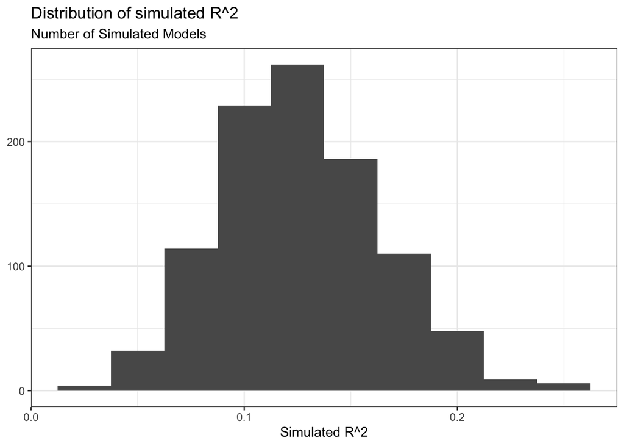

```r
set.seed(222)
model_lm <- lm(avg_fertility ~ avg_gdp, data = avg_fertility_gdp)
model_predict <- predict(model_lm)
model_sigma <- sigma(model_lm)
noise <- function(x, mean = 0, sd){
  x + rnorm(length(x),
            mean,
            sd)
}
sim_response <- tibble(sim_fertility = noise(model_predict,
                                             sd = model_sigma))
sim_data <- avg_fertility_gdp |>
  filter(!is.na(avg_fertility),
         !is.na(avg_gdp)) |>
  select(avg_fertility, avg_gdp) |>
  bind_cols(sim_response)

#lm(avg_fertility ~ sim_fertility, data = sim_data) |>
 # glance()

sim_r2 <- lm(avg_fertility ~sim_fertility, data = sim_data) |>
  glance() |>
  select(r.squared) |>
  pull()

sims <- map_dfc(.x = 1:1000,
                .f = ~tibble(sim = noise(model_predict,
                                         sd = model_sigma)))
colnames(sims) <- colnames(sims) |>
  str_replace(pattern = "\\.\\.\\.",
                  replace = "_")

sims <- avg_fertility_gdp |>
  filter(!is.na(avg_fertility),
         !is.na(avg_gdp)) |>
  select(avg_fertility) |>
  bind_cols(sims)

sims_r_squared <- sims |>
  map( ~ lm(avg_fertility ~ .x, data=sims)) |>
  map(glance) |>
  map_dbl(~.x$r.squared)

sims_r_squared <- sims_r_squared[names(sims_r_squared) != "avg_fertility"]

tibble(sims = sims_r_squared) |>
  ggplot(aes(x = sims)) +
  geom_histogram(binwidth = 0.025) +
  labs(x = "Simulated R^2",
       y= NULL,
       subtitle = "Number of Simulated Models",
       title = "Distribution of simulated R^2") +
  theme_bw()
```

Ideally, we would want the center of the distribution to fall near 1. An $R^2$ value of 1 would indicate that our simulated data explains 100% of the variability in our observed data, meaning it is a perfect fit. In the distribution we can see that the majority of the $R^2$ values fall around 0.125. This means that over the 1000 simulations, the majority of our generated data sets explained 12.5% of the variability in the observed data. This means that our model is not a great fit.

# Conclusion

To conclude, through our exploration we confirmed that average GDP and average fertility rate have a negative association. GDP is also a statistically significant predictor of fertility rate, since the p-value for the slope coefficient of average GDP is very small (<0.001). However, using our proposed linear regression model to model this relationship is evidently not adequate, as our model does not perform considerably well, as identified in section 3.2. Our linear regression being a poor model may have been expected, as the data does not meet all the linear regression requirements, as identified in section 2.2.

If we were to have included other variables in the model, transformed the variables, or included higher order terms our model may have performed better at predicting the average fertility rate in a given country. Future studies might also look into choosing a different modeling method than linear regression, such as logistic regression.

# References

“Babies per Woman (Total Fertility Rate) | Gapminder.” Gapminder.org, 2021, www.gapminder.org/data/documentation/gd008/. Accessed 16 Mar. 2024.

“GDP per Capita in Constant PPP Dollars | Gapminder.” Gapminder.org, 2017, www.gapminder.org/data/documentation/gd001/. Accessed 16 Mar. 2024.

Vandenbroucke, Guillaume. “The Link between Fertility and Income.” Stlouisfed.org, Federal Reserve Bank of St. Louis, 13 Dec. 2016, www.stlouisfed.org/on-the-economy/2016/december/link-fertility-income. Accessed 16 Mar. 2024.